# Datentransformation mit dplyr

Dr. Wasilios Hariskos

# Der gapminder Datensatz

```r
# install.packages("gapminder")
library(gapminder)
gapminder
```

```
## # A tibble: 1,704 x 6
##    country     continent  year lifeExp      pop gdpPercap
##    <fct>       <fct>     <int>   <dbl>    <int>     <dbl>
##  1 Afghanistan Asia       1952    28.8  8425333      779.
##  2 Afghanistan Asia       1957    30.3  9240934      821.
##  3 Afghanistan Asia       1962    32.0 10267083      853.
##  4 Afghanistan Asia       1967    34.0 11537966      836.
##  5 Afghanistan Asia       1972    36.1 13079460      740.
##  6 Afghanistan Asia       1977    38.4 14880372      786.
##  7 Afghanistan Asia       1982    39.9 12881816      978.
##  8 Afghanistan Asia       1987    40.8 13867957      852.
##  9 Afghanistan Asia       1992    41.7 16317921      649.
## 10 Afghanistan Asia       1997    41.8 22227415      635.
## # ... with 1,694 more rows
```

In diesem Modul werden wir den Datensatz gapminder benutzen, welcher demographische Länderdaten enthält. Wenn Sie `?gapminder` in die Konsole eingeben, können Sie mehr über diesen Datensatz herausfinden. Bitte beachten Sie, dass der gapminder Datensatz als tibble abgespeichert ist, eine moderne Form des traditionellen data frames. Mit `?tibble` können Sie mehr über tibbles herausfinden.

# Das dplyr Packet instalieren und laden

```r
# install.packages("dplyr")
library(dplyr)
```

## Einen Einblick in die Daten erhalten

```r
glimpse(gapminder)
```

```
## Observations: 1,704
## Variables: 6
## $ country   <fct> Afghanistan, Afghanistan, Afghanistan, Afghanistan, Afgha...
## $ continent <fct> Asia, Asia, Asia, Asia, Asia, Asia, Asia, Asia, Asia, Asi...
## $ year      <int> 1952, 1957, 1962, 1967, 1972, 1977, 1982, 1987, 1992, 199...
## $ lifeExp   <dbl> 28.801, 30.332, 31.997, 34.020, 36.088, 38.438, 39.854, 4...
## $ pop       <int> 8425333, 9240934, 10267083, 11537966, 13079460, 14880372,...
## $ gdpPercap <dbl> 779.4453, 820.8530, 853.1007, 836.1971, 739.9811, 786.113...
```

## Vergleich: glimpse() vs str()

```r
str(gapminder)
```

```
## Classes 'tbl_df', 'tbl' and 'data.frame':    1704 obs. of  6 variables:
##  $ country  : Factor w/ 142 levels "Afghanistan",..: 1 1 1 1 1 1 1 1 1 1 ...
##  $ continent: Factor w/ 5 levels "Africa","Americas",..: 3 3 3 3 3 3 3 3 3 3 ...
##  $ year     : int  1952 1957 1962 1967 1972 1977 1982 1987 1992 1997 ...
##  $ lifeExp  : num  28.8 30.3 32 34 36.1 ...
##  $ pop      : int  8425333 9240934 10267083 11537966 13079460 14880372 12881816 13867957 16317921 22227415 ...
##  $ gdpPercap: num  779 821 853 836 740 ...
```

Geben Sie `?glimpse` in die Konsole ein, um mehr über diese Funktion zu erfahren. Mit der Funktion `View()` können Sie den gesamten Datensatz einsehen. Probieren Sie es aus.

# Beobachtugen nach Kriterien filtern mit filter()

## Ein Kriterium: Land ist gleich Deutschland

```r
gapminder %>%
  filter(country == "Germany")
```

```
## # A tibble: 12 x 6
##    country continent  year lifeExp      pop gdpPercap
##    <fct>   <fct>     <int>   <dbl>    <int>     <dbl>
##  1 Germany Europe     1952    67.5 69145952     7144.
##  2 Germany Europe     1957    69.1 71019069    10188.
##  3 Germany Europe     1962    70.3 73739117    12902.
##  4 Germany Europe     1967    70.8 76368453    14746.
##  5 Germany Europe     1972    71   78717088    18016.
##  6 Germany Europe     1977    72.5 78160773    20513.
##  7 Germany Europe     1982    73.8 78335266    22032.
##  8 Germany Europe     1987    74.8 77718298    24639.
##  9 Germany Europe     1992    76.1 80597764    26505.
## 10 Germany Europe     1997    77.3 82011073    27789.
## 11 Germany Europe     2002    78.7 82350671    30036.
## 12 Germany Europe     2007    79.4 82400996    32170.
```

## Zwei Kriterien: Land ist gleich Deutschland & Jahr ist größer-gleich 1982

```r
gapminder %>%
  filter(country == "Germany",
         year >= 1982)
```

```
## # A tibble: 6 x 6
##   country continent  year lifeExp      pop gdpPercap
##   <fct>   <fct>     <int>   <dbl>    <int>     <dbl>
## 1 Germany Europe     1982    73.8 78335266    22032.
## 2 Germany Europe     1987    74.8 77718298    24639.
## 3 Germany Europe     1992    76.1 80597764    26505.
## 4 Germany Europe     1997    77.3 82011073    27789.
## 5 Germany Europe     2002    78.7 82350671    30036.
## 6 Germany Europe     2007    79.4 82400996    32170.
```

# Beobachtungen ordnen mit arrange()

## Ordnen von geringer zu hoher Lebenserwartung

```r
gapminder %>%
  filter(year == 1997,
         continent == "Europe") %>%
  arrange(lifeExp) %>%
  print(n = 20)
```

```
## # A tibble: 30 x 6
##    country                continent  year lifeExp      pop gdpPercap
##    <fct>                  <fct>     <int>   <dbl>    <int>     <dbl>
##  1 Turkey                 Europe     1997    68.8 63047647     6601.
##  2 Romania                Europe     1997    69.7 22562458     7347.
##  3 Bulgaria               Europe     1997    70.3  8066057     5970.
##  4 Hungary                Europe     1997    71.0 10244684    11713.
##  5 Serbia                 Europe     1997    72.2 10336594     7914.
##  6 Slovak Republic        Europe     1997    72.7  5383010    12126.
##  7 Poland                 Europe     1997    72.8 38654957    10160.
##  8 Albania                Europe     1997    73.0  3428038     3193.
##  9 Bosnia and Herzegovina Europe     1997    73.2  3607000     4766.
## 10 Croatia                Europe     1997    73.7  4444595     9876.
## 11 Czech Republic         Europe     1997    74.0 10300707    16049.
## 12 Slovenia               Europe     1997    75.1  2011612    17161.
## 13 Montenegro             Europe     1997    75.4   692651     6466.
## 14 Portugal               Europe     1997    76.0 10156415    17641.
## 15 Denmark                Europe     1997    76.1  5283663    29804.
## 16 Ireland                Europe     1997    76.1  3667233    24522.
## 17 Finland                Europe     1997    77.1  5134406    23724.
## 18 United Kingdom         Europe     1997    77.2 58808266    26075.
## 19 Germany                Europe     1997    77.3 82011073    27789.
## 20 Austria                Europe     1997    77.5  8069876    29096.
## # ... with 10 more rows
```

## Ordnen von hoher zu geringer Lebenserwartung

```r
countries <- c("Germany", "Greece", "Portugal", "Spain", "Singapore", "Serbia", "India", "United States")

gapminder %>%
  filter(year == 1982,
         country %in% countries) %>%
  arrange(desc(lifeExp))
```

```
## # A tibble: 8 x 6
##   country       continent  year lifeExp       pop gdpPercap
##   <fct>         <fct>     <int>   <dbl>     <int>     <dbl>
## 1 Spain         Europe     1982    76.3  37983310    13926.
## 2 Greece        Europe     1982    75.2   9786480    15268.
## 3 United States Americas   1982    74.6 232187835    25010.
## 4 Germany       Europe     1982    73.8  78335266    22032.
## 5 Portugal      Europe     1982    72.8   9859650    11754.
## 6 Singapore     Asia       1982    71.8   2651869    15169.
## 7 Serbia        Europe     1982    70.2   9032824    15181.
## 8 India         Asia       1982    56.6 708000000      856.
```

# Veränderen oder Erstellen von Variablen mit mutate()

```r
gapminder %>%
  mutate(pop = pop / 1000000)
```

```
## # A tibble: 1,704 x 6
##    country     continent  year lifeExp   pop gdpPercap
##    <fct>       <fct>     <int>   <dbl> <dbl>     <dbl>
##  1 Afghanistan Asia       1952    28.8  8.43      779.
##  2 Afghanistan Asia       1957    30.3  9.24      821.
##  3 Afghanistan Asia       1962    32.0 10.3       853.
##  4 Afghanistan Asia       1967    34.0 11.5       836.
##  5 Afghanistan Asia       1972    36.1 13.1       740.
##  6 Afghanistan Asia       1977    38.4 14.9       786.
##  7 Afghanistan Asia       1982    39.9 12.9       978.
##  8 Afghanistan Asia       1987    40.8 13.9       852.
##  9 Afghanistan Asia       1992    41.7 16.3       649.
## 10 Afghanistan Asia       1997    41.8 22.2       635.
## # ... with 1,694 more rows
```

```r
gapminder %>%
  mutate(popMM = pop / 1000000)
```

```
## # A tibble: 1,704 x 7
##    country     continent  year lifeExp      pop gdpPercap popMM
##    <fct>       <fct>     <int>   <dbl>    <int>     <dbl> <dbl>
##  1 Afghanistan Asia       1952    28.8  8425333      779.  8.43
##  2 Afghanistan Asia       1957    30.3  9240934      821.  9.24
##  3 Afghanistan Asia       1962    32.0 10267083      853. 10.3
##  4 Afghanistan Asia       1967    34.0 11537966      836. 11.5
##  5 Afghanistan Asia       1972    36.1 13079460      740. 13.1
##  6 Afghanistan Asia       1977    38.4 14880372      786. 14.9
##  7 Afghanistan Asia       1982    39.9 12881816      978. 12.9
##  8 Afghanistan Asia       1987    40.8 13867957      852. 13.9
##  9 Afghanistan Asia       1992    41.7 16317921      649. 16.3
## 10 Afghanistan Asia       1997    41.8 22227415      635. 22.2
## # ... with 1,694 more rows
```

# Das Kombinieren von filter(), arrange(), and mutate()

```r
gdp_1997 <- gapminder %>%
  mutate(gdp = gdpPercap * pop) %>%
  filter(year == 1997) %>%
  arrange(desc(gdp))
gdp_1997
```

```
## # A tibble: 142 x 7
##    country        continent  year lifeExp        pop gdpPercap     gdp
##    <fct>          <fct>     <int>   <dbl>      <int>     <dbl>   <dbl>
##  1 United States  Americas   1997    76.8  272911760    35767. 9.76e12
##  2 Japan          Asia       1997    80.7  125956499    28817. 3.63e12
##  3 China          Asia       1997    70.4 1230075000     2289. 2.82e12
##  4 Germany        Europe     1997    77.3   82011073    27789. 2.28e12
##  5 United Kingdom Europe     1997    77.2   58808266    26075. 1.53e12
##  6 France         Europe     1997    78.6   58623428    25890. 1.52e12
##  7 Italy          Europe     1997    78.8   57479469    24675. 1.42e12
##  8 India          Asia       1997    61.8  959000000     1459. 1.40e12
##  9 Brazil         Americas   1997    69.4  168546719     7958. 1.34e12
## 10 Mexico         Americas   1997    73.7   95895146     9767. 9.37e11
## # ... with 132 more rows
```

```r
# Exkurs: Scientific form (exponential form)
non_scientific <- format(gdp_1997$gdp[1:3], scientific = FALSE)
non_scientific
```

```
## [1] "9761353098899" "3629636158476" "2815929679840"
```

```r
scientific <- c(9.7613, 3.6296, 2.8159) * 10^12
scientific
```

```
## [1] 9.7613e+12 3.6296e+12 2.8159e+12
```

# Nutzung von summarize(), um numerische Zusammenfassungen zu erstellen

## Die mittlere Lebenserwartung über alle Länder im Jahr 1997

```r
gdp_1997 %>%
  summarize(meanLifeExp = mean(lifeExp))
```

```
## # A tibble: 1 x 1
##   meanLifeExp
##         <dbl>
## 1        65.0
```

```r
gdp_1997 %>%
  summarize(meanLifeExp = mean(lifeExp),
            totalPop = sum(as.numeric(pop)))
```

```
## # A tibble: 1 x 2
##   meanLifeExp   totalPop
##         <dbl>      <dbl>
## 1        65.0 5515204472
```

## Weitere deskriptive Statistiken hinzufügen

```r
gdp_1997 %>%
  summarize(meanLifeExp = mean(lifeExp),
            medianLifeExp = median(lifeExp),
            minGdpPercap = min(gdpPercap),
            maxGdpT = max(gdp/1e12),
            totalPopB = sum(pop/1e9))
```

```
## # A tibble: 1 x 5
##   meanLifeExp medianLifeExp minGdpPercap maxGdpT totalPopB
##         <dbl>         <dbl>        <dbl>   <dbl>     <dbl>
## 1        65.0          69.4         312.    9.76      5.52
```

## Exkurs: Englische Abkürzungen für große Zahlen

- Thousand (tausend): 1,000 or 1e03 or 1K or 1M. M being the Roman numeral for 1,000.
- Million (Million = tausend mal tausend): 1,000,000 or 1e06 or 1MM. MM means “thousands (times) thousands”.
- Billion (Milliarde = tausend Millionen): 1,000,000,000 or 1e09 or 1B.
- Trillion (Billion = ein Million Millionen): 1,000,000,000,000 or 1e12 or 1T.

## Numerische Zusammenfassung nach Jahren mit group_by()

```r
gapminder %>%
  group_by(year) %>%
  summarize(meanLifeExp = mean(lifeExp),
            medianLifeExp = median(lifeExp),
            minGdpPercap = min(gdpPercap),
            maxGdpT = max((gdpPercap * pop)/1e12),
            totalPopB = sum(pop/1e9))
```

```
## # A tibble: 12 x 6
##     year meanLifeExp medianLifeExp minGdpPercap maxGdpT totalPopB
##  * <int>       <dbl>         <dbl>        <dbl>   <dbl>     <dbl>
##  1  1952        49.1          45.1         299.    2.20      2.41
##  2  1957        51.5          48.4         336.    2.55      2.66
##  3  1962        53.6          50.9         355.    3.02      2.90
##  4  1967        55.7          53.8         349     3.88      3.22
##  5  1972        57.6          56.5         357     4.58      3.58
##  6  1977        59.6          59.7         371     5.30      3.93
##  7  1982        61.5          62.4         424     5.81      4.29
##  8  1987        63.2          65.8         385     7.26      4.69
##  9  1992        64.2          67.7         347     8.22      5.11
## 10  1997        65.0          69.4         312.    9.76      5.52
## 11  2002        65.7          70.8         241.   11.2       5.89
## 12  2007        67.0          71.9         278.   12.9       6.25
```

## Numerische Zusammenfassung nach Kontintent und Jahr mit group_by()

```r
by_continent_year <- gapminder %>%
  group_by(continent, year) %>%
  summarize(meanLifeExp = mean(lifeExp),
            medianLifeExp = median(lifeExp),
            minGdpPercap = min(gdpPercap),
            maxGdpT = max((gdpPercap * pop)/1e12),
            totalPopB = sum(pop/1e9))
print(by_continent_year, n = 20)
```

```
## # A tibble: 60 x 7
## # Groups:   continent [5]
##    continent  year meanLifeExp medianLifeExp minGdpPercap maxGdpT totalPopB
##    <fct>     <int>       <dbl>         <dbl>        <dbl>   <dbl>     <dbl>
##  1 Africa     1952        39.1          38.8         299.  0.0674     0.238
##  2 Africa     1957        41.3          40.6         336.  0.0886     0.265
##  3 Africa     1962        43.3          42.6         355.  0.106      0.297
##  4 Africa     1967        45.3          44.7         413.  0.149      0.335
##  5 Africa     1972        47.5          47.0         464.  0.186      0.380
##  6 Africa     1977        49.6          49.3         502.  0.218      0.433
##  7 Africa     1982        51.6          50.8         462.  0.267      0.499
##  8 Africa     1987        53.3          51.6         390.  0.281      0.575
##  9 Africa     1992        53.6          52.4         411.  0.289      0.659
## 10 Africa     1997        53.6          52.8         312.  0.320      0.744
## 11 Africa     2002        53.3          51.2         241.  0.349      0.834
## 12 Africa     2007        54.8          52.9         278.  0.448      0.930
## 13 Americas   1952        53.3          54.7        1398.  2.20       0.345
## 14 Americas   1957        56.0          56.1        1544.  2.55       0.387
## 15 Americas   1962        58.4          58.3        1662.  3.02       0.433
## 16 Americas   1967        60.4          60.5        1452.  3.88       0.481
## 17 Americas   1972        62.4          63.4        1654.  4.58       0.529
## 18 Americas   1977        64.4          66.4        1874.  5.30       0.578
## 19 Americas   1982        66.2          67.4        2011.  5.81       0.630
## 20 Americas   1987        68.1          69.5        1823.  7.26       0.683
## # ... with 40 more rows
```

# Ausblick: Visualisierung von numerischen Zusammenfassungen mit ggplot2

```r
# install.packages("ggplot2")
library(ggplot2)
```

Starte das ggplot Objekt und deklariere den Datensatz. Nutzen Sie `?ggplot` für mehr Informationen.

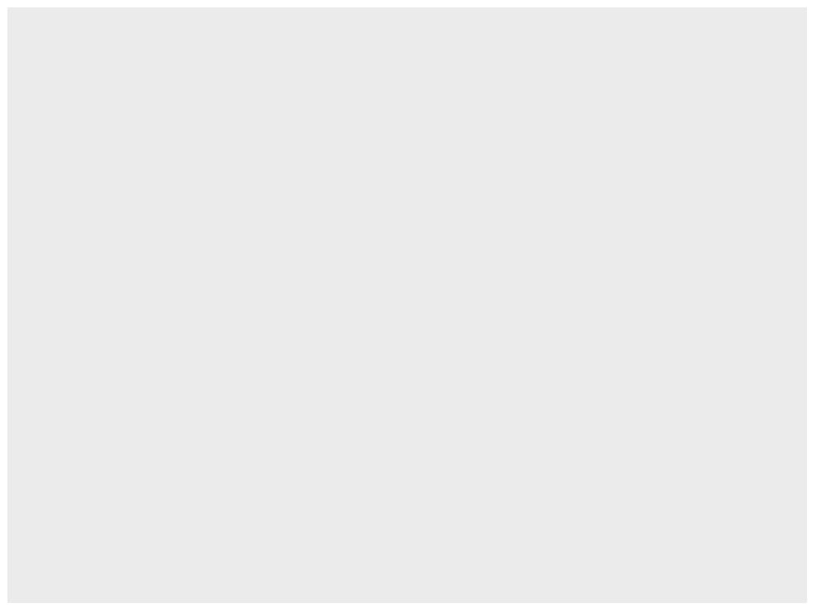

```r
ggplot(data = by_continent_year)
```

Fügen Sie ein point geom hinzu, um ein Streudiagramm mit Aesthetik-Abbildungen: x-Achse gleich Jahr, y-Achse gleich mittlere Lebenserwartung. Für mehr Informationen, nutzen Sie `?geom_point` und `?aes`.

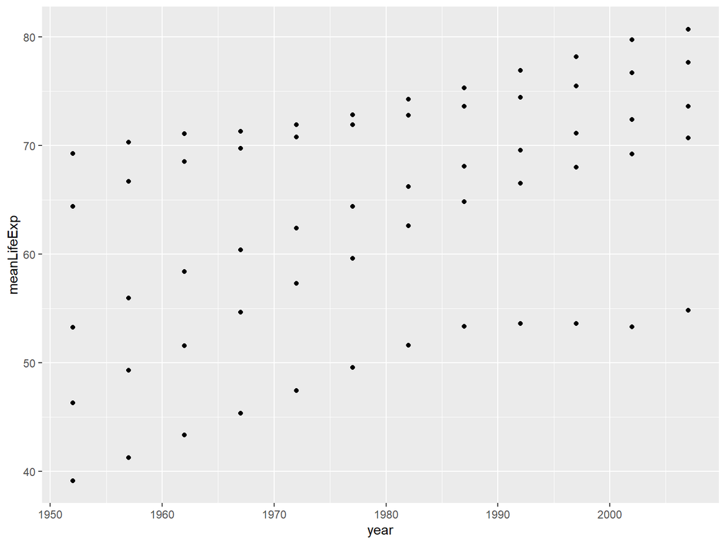

```r
ggplot(data = by_continent_year) +
  geom_point(mapping = aes(x = year,
                           y = meanLifeExp))
```

Bilden Sie den Kontinent auf die color Aesthetik ab.

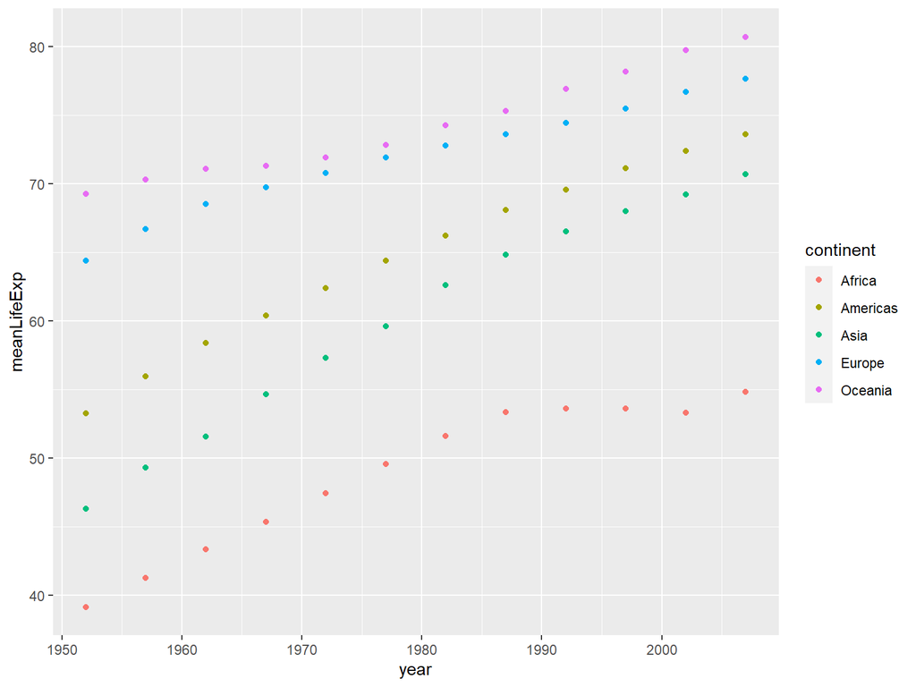

```r
ggplot(data = by_continent_year) +
  geom_point(mapping = aes(x = year,
                           y = meanLifeExp,
                           color = continent))
```

Bilden Sie den Populationsgröße auf die size Aesthetik ab.

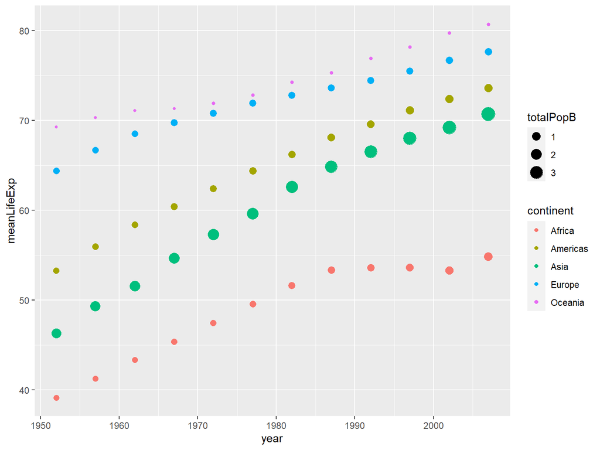

```r
ggplot(data = by_continent_year) +
  geom_point(mapping = aes(x = year,
                           y = meanLifeExp,
                           color = continent,
                           size = totalPopB))
```